# DV Assignment 2, Part 1: Which schools in a municipality are on track for reading and maths?

Group 6: Míra Sopuch, Kassandra Vroulli, Luna van Wonderen

2026-10-04

## Research question

**What is your research question?** Which schools in Amstelveen are on track for reading and maths?

**Is it a question of analytics, inference or prediction?** Analytics- the goal is to describe and compare school performance across Amstelveen and identify which schools are on track with the national benchmark for the higher reference levels in maths (1S) and reading (2F).

**Who is the target audience for your final visualization, and how does that shape your choices?** The target audience is a municipal education officer or school board. The visualizations should be clear and easy to interpret, allowing for quick comparison between schools. An education officer must see at a glance which schools fall behind, so we use school names, a clear benchmark line and in one case traffic-light colours.

## Exploratory process

**Describe how you explored the data. Include at least one exploratory visualization below, and a short note on what it shows, and what you learned from it about your research question.**

```r
# Select relevant reference-level variables
count_cols <- c("REKENEN_LAGER1F", "REKENEN_1F", "REKENEN_1S",
                "LV_LAGER1F", "LV_1F", "LV_2F")

# value for DUO's "<5": the midpoint
lt5_value <- 2.5

replace_lt5 <- function(x) {
  x <- as.character(x)
  as.numeric(if_else(x == "<5", as.character(lt5_value), x))
}

# Convert columns to numeric, and turn values like <5 into 2.5
# Clean reference-level counts
ref_levels <- referentieniveaus |>
  # Used to turn <5 into NA, now into 2.5 to prevent false 100% scores.
  # For small schools, this quite greatly influenced averages for example.
  mutate(across(all_of(count_cols), replace_lt5)) |>
  group_by(INSTELLINGSCODE) |>
  summarise(
    GEMEENTENAAM = first(GEMEENTENAAM),
    INSTELLINGSNAAM_VESTIGING = first(INSTELLINGSNAAM_VESTIGING),
    across(all_of(count_cols), ~ sum(.x, na.rm = TRUE)), .groups = "drop"
  ) |>
  mutate(
    # total number of students for maths and for reading
    rekenen_n = REKENEN_LAGER1F + REKENEN_1F + REKENEN_1S,
    reading_n = LV_LAGER1F + LV_1F + LV_2F,
    # percentage of students for each level
    math_1F = 100 * (REKENEN_1F + REKENEN_1S) / rekenen_n,
    math_1S = 100 * REKENEN_1S / rekenen_n,
    reading_1F = 100 * (LV_1F + LV_2F) / reading_n,
    reading_2F = 100 * LV_2F / reading_n
  ) |>
  # filter out schools where no pupils are counted for maths and reading,
  # this might not occur for Amstelveen, but is necessary for calculating
  # averages.
  filter(rekenen_n > 0, reading_n > 0)

# calculate Schoolweging
school_weights <- schoolweging |>
  mutate(INSTELLINGSCODE = str_remove(OVT, "\\|.*$")) |>
  group_by(INSTELLINGSCODE) |>
  summarise(
    schoolweging = weighted.mean(schoolweging, w = aantal_leerlingen),
    .groups = "drop"
  )

# Combine reference-level results with schoolweging
school_data <- left_join(ref_levels, school_weights, by = "INSTELLINGSCODE")

# Amstelveen Gemeente
amstelveen_data <- filter(school_data, GEMEENTENAAM == "Amstelveen")

# Final data
amstelveen_data |>
  select(INSTELLINGSNAAM_VESTIGING, schoolweging,
         math_1F, math_1S, reading_1F, reading_2F)
```

```
## # A tibble: 20 × 6
##    INSTELLINGSNAAM_VESTIGING schoolweging math_1F math_1S reading_1F reading_2F
##    <chr>                            <dbl>   <dbl>   <dbl>      <dbl>      <dbl>
##  1 Brede School Omnibus              30.5   100      70.6      100         64.7
##  2 Basisschool Parcival              25.1   100      65.2      100         88.9
##  3 Roelof Venemaschool               22.5    97.0    63.9      100         91.6
##  4 Horizon                           33.3   100      25        100         71.4
##  5 De Cirkel                         27.3    81.8    34.5      100         72.7
##  6 Het Palet                         27.2   100      48.1       91.4       82.8
##  7 Willem Alexanderschool            25.3    95.7    61.5      100         87.7
##  8 Obs Michiel de Ruyter             24.7   100      65.5      100         76.4
##  9 Obs Piet Hein                     23.4    96.7    70.6       96.7       88.9
## 10 Mio Mondo                         25.6    94.3    48.3       94.3       78.2
## 11 Kindercampus King                 28.1    94.1    65.9      100         94.1
## 12 Obs de Linde                      26.2    91.5    40.7      100         71.4
## 13 Obs de Pioniers                   30.4    86.7    53.3       94.6       68.8
## 14 De Akker                          29.5    84.8    30.3      100         81.5
## 15 Triangel                          24.2    97.6    70.8      100         97.5
## 16 OBS de Westwijzer                 27.6    94.9    62.6      100         81.2
## 17 Karel Eykman school               24.7   100      60.8      100         88.6
## 18 Rembrandt                         22.5    95.5    73.9      100         95.3
## 19 School of Understanding           26.5   100      72.7      100         88.4
## 20 Elif Amstelveen                   33.9   100      23.8      100         73.7
```

```r
# National benchmark
national <- school_data |>
  summarise(
    # weighted.mean is weighted by the number of pupils. A school with 80
    # pupils counts more than a school with 10.
    math_1S = weighted.mean(math_1S, w = rekenen_n),
    reading_2F = weighted.mean(reading_2F, w = reading_n)
  )

national
```

```
## # A tibble: 1 × 2
##   math_1S reading_2F
##     <dbl>      <dbl>
## 1    42.9       73.0
```

### Exploratory Plot 1

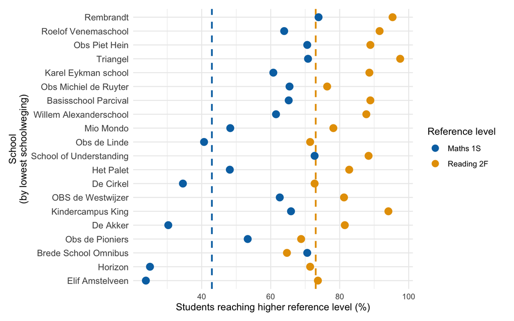

```r
#Select data for plot
plot_data <- amstelveen_data |>
  select(
    INSTELLINGSNAAM_VESTIGING,
    schoolweging,
    math_1S,
    reading_2F
  ) |>
  pivot_longer(
    cols = c(math_1S, reading_2F),
    names_to = "level",
    values_to = "percentage"
  )

#National benchmark for each higher reference level
national_plot <- tibble(
  level = c("math_1S", "reading_2F"),
  benchmark = c(
    national$math_1S,
    national$reading_2F
  )
)

#Create plot 1
plot1 <- ggplot(
  plot_data,
  aes(x = percentage,
      y = reorder(INSTELLINGSNAAM_VESTIGING, -schoolweging),
      colour = level)
) +
  geom_vline(
    data = national_plot,
    aes(xintercept = benchmark, colour = level),
    linetype = "dashed",
    linewidth = 0.9
  ) +
  geom_point(size = 3.5) +
  scale_colour_manual(
    values = c(
      "math_1S" = "#0072B2",
      "reading_2F" = "#E69F00"
    ),
    labels = c(
      "math_1S" = "Maths 1S",
      "reading_2F" = "Reading 2F"
    )
  ) +
  labs(
    x = "Students reaching higher reference level (%)",
    y = "School\n(by lowest schoolweging)",
    colour = "Reference level"
  ) +
  guides(
    colour = guide_legend(
      override.aes = list(
        linetype = 0,
        shape = 16,
        size = 3.5
      )
    )
  ) +
  theme_minimal() +
  theme(
    legend.position = "right",
    panel.grid.major.x = element_line(linewidth = 0.5),
    axis.text.y = element_text(size = 10),
    plot.margin = margin(10, 15, 10, 10)
  )

plot1
```

Plot 1 visualizes the percentage of students that reach the higher reference levels for maths (1S) and reading (2F) in each primary school in Amstelveen. It shows which schools are on track with the national benchmarks (dashed lines) and which perform below.

### Exploratory plot 2

```r
scatterplot_data <- amstelveen_data |>
  select(INSTELLINGSNAAM_VESTIGING, schoolweging, math_1S, reading_2F) |>
  pivot_longer(
    cols = c(math_1S, reading_2F),
    names_to = "level",
    values_to = "percentage"
  )

scatter_interactive <- ggplot(
  scatterplot_data,
  aes(schoolweging,
      percentage,
      colour = level)
) +
  geom_point(aes(
    text = paste0(
      "<b>", INSTELLINGSNAAM_VESTIGING, "</b>",
      "<br>", round(percentage, 2), "% reaching target level",
      "<br>School weighting: ", round(schoolweging, 2)
    )
  )
  ) +
  geom_smooth(method = "lm", se = FALSE, alpha = 0.1) +
  scale_colour_manual(
    values = c("math_1S" = "#0072B2", "reading_2F" = "#E69F00")
  ) +
  labs(
    title = "% of Students Reaching Higher Reference Level by School Weighting",
    x = "School weighting (higher = more disadvantaged)",
    y = "Percentage",
    colour = "Level"
  ) +
  theme_bw()

ggplotly(scatter_interactive, tooltip = "text")
```

[interactive chart not shown]

The above plot displays the percentage of students reaching the higher reference level by school weighting and subject. More students reach the target level in reading (yellow) than in math (blue), and students from more disadvantaged schools perform worse.

### Exploratory plot 3

#### Check <5

In a first version of the scatterplot, where “<5” was treated as 0 (as in Assignment 1), 8 Amstelveen schools appeared at exactly 100% reading. The check below shows why.

```r
# 8 schools at 100% reading, this could be due to the <5 being
# transformed into 0 for 1F, due to which 'all' pupils appeared to have
# reached 2F.
# check this:
referentieniveaus |>
  filter(GEMEENTENAAM == "Amstelveen") |>
  select(INSTELLINGSNAAM_VESTIGING, LV_LAGER1F, LV_1F, LV_2F)
```

```
## # A tibble: 20 × 4
##    INSTELLINGSNAAM_VESTIGING LV_LAGER1F LV_1F LV_2F
##    <chr>                     <chr>      <chr> <chr>
##  1 Brede School Omnibus      0          6     11
##  2 Basisschool Parcival      0          <5    20
##  3 Roelof Venemaschool       0          7     76
##  4 Horizon                   0          8     20
##  5 De Cirkel                 0          15    40
##  6 Het Palet                 <5         <5    24
##  7 Willem Alexanderschool    0          7     50
##  8 Obs Michiel de Ruyter     0          13    42
##  9 Obs Piet Hein             <5         6     68
## 10 Mio Mondo                 <5         7     34
## 11 Kindercampus King         0          <5    40
## 12 Obs de Linde              0          8     20
## 13 Obs de Pioniers           <5         12    32
## 14 De Akker                  0          <5    11
## 15 Triangel                  0          <5    99
## 16 OBS de Westwijzer         0          9     39
## 17 Karel Eykman school       0          9     70
## 18 Rembrandt                 0          <5    51
## 19 School of Understanding   0          <5    19
## 20 Elif Amstelveen           0          <5    7
```

```r
# appears that Parcival, het Palet, Kindercampus King, de Akker,
# de Triangel, Rembrandt, School of Understanding and Elif Amstelveen
# possibly do not really score 100%. Based on this, decided to change the
# schools that had <5 pupils to 2.5 instead of the original 0 as to not
# report untrue 100% scores.
```

#### Create quadrant names

```r
amstelveen_data <- amstelveen_data |>
  mutate(
    maths_above = math_1S >= national$math_1S,
    reading_above = reading_2F >= national$reading_2F,
    quadrant = case_when(
      maths_above & reading_above ~ "Above average in both",
      !maths_above & !reading_above ~ "Below average in both",
      TRUE ~ "Above average in one subject"
    )
  )
```

#### Exploratory plot

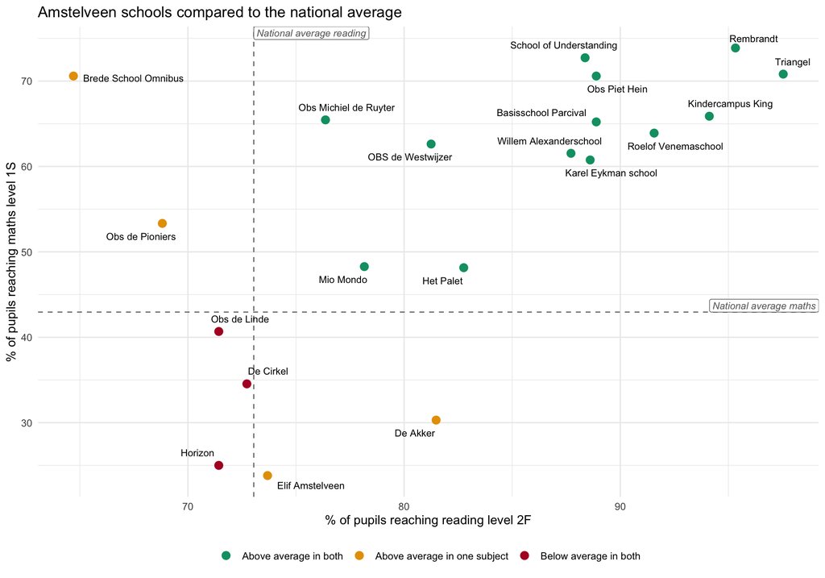

```r
# one-row data frames to label the two national average lines
reading_label <- tibble(
  x = national$reading_2F,
  y = Inf,
  label = "National average reading"
)
maths_label <- tibble(
  x = Inf,
  y = national$math_1S,
  label = "National average maths"
)
ggplot(data = amstelveen_data,
       mapping = aes(x = reading_2F, y = math_1S)) +
  geom_vline(xintercept = national$reading_2F,
             linetype = "dashed", color = "grey50") +
  geom_hline(yintercept = national$math_1S,
             linetype = "dashed", color = "grey50") +
  geom_label(data = reading_label, aes(x = x, y = y, label = label),
             hjust = 0, vjust = 1, size = 3, fontface = "italic",
             color = "grey40") +
  geom_label(data = maths_label, aes(x = x, y = y, label = label),
             hjust = 1, vjust = 0, size = 3, fontface = "italic",
             color = "grey40") +
  geom_point(aes(color = quadrant), size = 3) +
  geom_text_repel(aes(label = INSTELLINGSNAAM_VESTIGING), size = 3,
                  box.padding = 0.5, seed = 1, segment.color = NA) +
  scale_color_manual(
    values = c(
      # colours also visible for colour-blind readers!
      "Above average in both" = "#009E73",
      "Above average in one subject" = "#E69F00",
      "Below average in both" = "#B2182B"
    ),
    breaks = c(
      "Above average in both",
      "Above average in one subject",
      "Below average in both"
    )
  ) +
  labs(
    title = "Amstelveen schools compared to the national average",
    x = "% of pupils reaching reading level 2F",
    y = "% of pupils reaching maths level 1S",
    color = NULL
  ) +
  theme_minimal() +
  theme(legend.position = "bottom")
```

Plot 3 compares each Amstelveen school to the national averages for maths (1S) and reading (2F), which split the plot into four quadrants. Most schools (13 of 20) score above the national average in both subjects, four score above average in one subject while Obs de Linde, De Cirkel and Horizon score below average in both.